# Analyse des données boursières par le clustering

## Realise par : Donovan Daniel Del Valle Jimenez

```python
import sklearn
import numpy as np
import scipy as sp
import pandas as pd
from collections import Counter
from sklearn.decomposition import PCA
from sklearn.preprocessing import StandardScaler
from sklearn.preprocessing import MinMaxScaler
import matplotlib.pyplot as plt
from sklearn.cluster import KMeans
from scipy.spatial.distance import cdist
from sklearn.metrics import silhouette_samples, silhouette_score
from sklearn.metrics import rand_score
import math
```

Données : L’ensemble (le tableau) de données contient 288 colonnes dont la première représente le temps et les 287 autres représentent des différentes séries chronologiques correspondant aux différents indices, ETFs, actions, etc. Il y a exactement une valeur (prix de clôture) par jour ouvrable. La longeur de chaque série est de 5221 correspondant aux 5221 jours ouvrables du 2000-12-29 au 2021-03-23. Il n’y a pas de problème de données manquantes avec cet ensemble de données.

```python
#Chargement des données
data_file = 'res_2000.csv'
data = pd.read_csv(data_file, index_col=0)
```

```python
#Il y a 5221 dates et 288 attributs
data.shape
```

```
(5221, 287)
```

```python
data.head(10)
```

| x | FPX1 | SHCP | SPXX | SX5P | A.CWI | A.XUS | AUD. | BBG. | BBG.9 | BBG.G | ... | FDCPX | HSI | GSPTSE | GOLDPMGBD228NLBM | WILL4500IND | WILL4500PR | WILL5000IND | WILL5000INDFC | WILL5000PR | WILL5000PRFC |
| --- | --- | --- | --- | --- | --- | --- | --- | --- | --- | --- | --- | --- | --- | --- | --- | --- | --- | --- | --- | --- | --- |
| 2000-12-29 | 5926.42 | 2073.48 | 359.79 | 4557.13 | 100.00 | 100.00 | 0.556 | 930.68 | 1031.64 | 1052.19 | ... | 48.034107 | 15095.53027 | 8933.700195 | 274.45 | 5.44 | 415.27 | 39.80 | 39.80 | 12175.88 | 12175.88 |
| 2001-01-02 | 5798.90 | 2103.47 | 354.83 | 4492.27 | 98.50 | 99.55 | 0.559 | 938.84 | 1041.97 | 1062.98 | ... | 43.306885 | 14869.94043 | 8611.500000 | 271.10 | 5.14 | 392.67 | 38.46 | 38.46 | 11763.92 | 11763.92 |
| 2001-01-03 | 5684.05 | 2123.90 | 351.38 | 4456.97 | 100.52 | 98.95 | 0.563 | 933.62 | 1035.56 | 1055.14 | ... | 51.329395 | 14589.58008 | 8937.799805 | 267.15 | 5.46 | 416.89 | 40.48 | 40.48 | 12380.26 | 12380.26 |
| 2001-01-04 | 5815.99 | 2117.41 | 356.54 | 4534.10 | 100.67 | 100.32 | 0.565 | 938.37 | 1041.96 | 1061.03 | ... | 51.109100 | 15235.03027 | 8905.700195 | 267.10 | 5.36 | 409.75 | 39.97 | 39.97 | 12224.42 | 12224.42 |
| 2001-01-05 | 5758.02 | 2125.30 | 355.10 | 4503.22 | 99.47 | 100.50 | 0.571 | 943.45 | 1048.96 | 1067.27 | ... | 47.097843 | 15447.61035 | 8690.200195 | 267.40 | 5.16 | 393.93 | 38.82 | 38.82 | 11872.66 | 11872.66 |
| 2001-01-08 | 5732.80 | 2102.06 | 353.65 | 4472.02 | 99.11 | 100.03 | 0.566 | 944.95 | 1051.95 | 1069.64 | ... | 46.996868 | 15436.53027 | 8671.700195 | 268.30 | 5.11 | 390.56 | 38.71 | 38.71 | 11836.45 | 11836.45 |
| 2001-01-09 | 5663.19 | 2101.14 | 350.77 | 4407.57 | 98.66 | 98.64 | 0.563 | 942.45 | 1048.03 | 1066.61 | ... | 47.510899 | 15500.58984 | 8572.000000 | 267.00 | 5.15 | 393.61 | 38.91 | 38.91 | 11896.98 | 11896.98 |
| 2001-01-10 | 5653.35 | 2125.62 | 348.83 | 4370.04 | 98.79 | 98.01 | 0.557 | 939.08 | 1043.48 | 1061.79 | ... | 49.667984 | 15435.79004 | 8600.799805 | 266.30 | 5.31 | 405.97 | 39.46 | 39.46 | 12064.50 | 12064.50 |
| 2001-01-11 | 5702.78 | 2119.14 | 352.12 | 4440.23 | 99.64 | 98.75 | 0.559 | 938.32 | 1044.77 | 1060.56 | ... | 53.128487 | 15090.76953 | 8805.400391 | 264.15 | 5.47 | 417.57 | 39.99 | 39.99 | 12227.44 | 12227.44 |
| 2001-01-12 | 5833.38 | 2032.44 | 355.98 | 4509.72 | 99.60 | 99.17 | 0.556 | 934.03 | 1038.99 | 1054.92 | ... | 52.403351 | 15295.41992 | 8716.400391 | 263.70 | 5.50 | 419.99 | 39.84 | 39.84 | 12181.33 | 12181.33 |

10 rows × 287 columns

```python
data.describe()
```

|  | FPX1 | SHCP | SPXX | SX5P | A.CWI | A.XUS | AUD. | BBG. | BBG.9 | BBG.G | ... | FDCPX | HSI | GSPTSE | GOLDPMGBD228NLBM | WILL4500IND | WILL4500PR | WILL5000IND | WILL5000INDFC | WILL5000PR | WILL5000PRFC |
| --- | --- | --- | --- | --- | --- | --- | --- | --- | --- | --- | --- | --- | --- | --- | --- | --- | --- | --- | --- | --- | --- |
| count | 5221.000000 | 5221.000000 | 5221.000000 | 5221.000000 | 5221.000000 | 5221.000000 | 5221.000000 | 5221.000000 | 5221.000000 | 5221.000000 | ... | 5221.000000 | 5221.000000 | 5221.000000 | 5221.000000 | 5221.000000 | 5221.000000 | 5221.000000 | 5221.000000 | 5221.000000 | 5221.000000 |
| mean | 4395.624493 | 2528.080098 | 308.279918 | 2953.032678 | 155.514195 | 163.272289 | 0.785216 | 1623.466573 | 1980.570948 | 1855.189127 | ... | 53.144038 | 20219.200259 | 12336.023604 | 1017.710094 | 12.530534 | 799.941663 | 70.624675 | 71.008439 | 17163.675468 | 17297.643938 |
| std | 852.445677 | 886.362234 | 62.677960 | 484.103459 | 63.218838 | 52.850000 | 0.142495 | 400.770807 | 575.698961 | 467.627833 | ... | 22.395047 | 5838.458836 | 3037.581345 | 478.603587 | 7.384326 | 405.198645 | 39.502714 | 39.630650 | 7617.761379 | 7672.484851 |
| min | 2403.040000 | 1011.500000 | 157.970000 | 1614.750000 | 59.890000 | 60.130000 | 0.483000 | 930.680000 | 1031.640000 | 1052.190000 | ... | 16.514481 | 8409.009766 | 5695.299805 | 255.950000 | 3.500000 | 261.440000 | 24.580000 | 24.580000 | 6800.080000 | 6858.430000 |
| 25% | 3710.610000 | 1766.480000 | 256.650000 | 2601.330000 | 103.590000 | 118.040000 | 0.707000 | 1232.550000 | 1440.450000 | 1407.830000 | ... | 33.581245 | 14976.259770 | 9902.799805 | 544.400000 | 6.710000 | 480.370000 | 40.580000 | 40.640000 | 11367.560000 | 11447.270000 |
| 50% | 4399.200000 | 2546.330000 | 313.680000 | 2922.720000 | 141.580000 | 171.380000 | 0.763000 | 1657.350000 | 2001.570000 | 1880.010000 | ... | 50.096455 | 21392.710940 | 12701.000000 | 1175.750000 | 9.570000 | 659.350000 | 53.330000 | 53.760000 | 14046.900000 | 14206.540000 |
| 75% | 5107.250000 | 3086.060000 | 364.390000 | 3219.520000 | 193.250000 | 199.380000 | 0.895000 | 1960.880000 | 2446.980000 | 2238.990000 | ... | 71.414421 | 24168.720700 | 14753.099610 | 1329.000000 | 17.340000 | 1082.790000 | 92.510000 | 93.530000 | 21666.060000 | 22027.650000 |
| max | 6168.150000 | 6092.060000 | 433.900000 | 4571.370000 | 348.300000 | 297.540000 | 1.103000 | 2400.810000 | 3114.060000 | 2812.350000 | ... | 120.519997 | 33154.121090 | 18983.099610 | 2067.150000 | 39.570000 | 2259.970000 | 198.770000 | 200.340000 | 41757.350000 | 42198.020000 |

8 rows × 287 columns

Ensuite, nous allons effectuer la normalisation des données, de manière à ce qu'il soit plus facile de les traiter. Nous allons également effectuer une transformation PCA en deux composants à appliquer avec DTW. Avec Kmeans il n'était pas nécessaire de travailler avec PCA, il était possible d'exécuter l'algorithme sans un temps d'exécution long, alors que DTW était très étendu.

```python
scaler = MinMaxScaler()
data_scaled = scaler.fit_transform(data)

pca2 = PCA(n_components=2)
pca2.fit(data_scaled)
data_pca2 = pca2.transform(data_scaled)
```

```python
data_pca = pd.DataFrame(data_pca2, index=data.index, columns = ['PCA1','PCA2'])
data_t = pd.DataFrame(data_scaled, index=data.index, columns = data.columns)
data_pca.index = data.index
```

```python
data_t.describe()
```

|  | FPX1 | SHCP | SPXX | SX5P | A.CWI | A.XUS | AUD. | BBG. | BBG.9 | BBG.G | ... | FDCPX | HSI | GSPTSE | GOLDPMGBD228NLBM | WILL4500IND | WILL4500PR | WILL5000IND | WILL5000INDFC | WILL5000PR | WILL5000PRFC |
| --- | --- | --- | --- | --- | --- | --- | --- | --- | --- | --- | --- | --- | --- | --- | --- | --- | --- | --- | --- | --- | --- |
| count | 5221.000000 | 5221.000000 | 5221.000000 | 5221.000000 | 5221.000000 | 5221.000000 | 5221.000000 | 5221.000000 | 5221.000000 | 5221.000000 | ... | 5221.000000 | 5221.000000 | 5221.000000 | 5221.000000 | 5221.000000 | 5221.000000 | 5221.000000 | 5221.000000 | 5221.000000 | 5221.000000 |
| mean | 0.529223 | 0.298506 | 0.544739 | 0.452639 | 0.331556 | 0.434448 | 0.487445 | 0.471242 | 0.455687 | 0.456208 | ... | 0.352189 | 0.477274 | 0.499761 | 0.420583 | 0.250361 | 0.269449 | 0.264336 | 0.264158 | 0.296465 | 0.295397 |
| std | 0.226407 | 0.174462 | 0.227152 | 0.163735 | 0.219198 | 0.222611 | 0.229830 | 0.272609 | 0.276457 | 0.265673 | ... | 0.215326 | 0.235944 | 0.228599 | 0.264247 | 0.204722 | 0.202748 | 0.226779 | 0.225482 | 0.217916 | 0.217107 |
| min | 0.000000 | 0.000000 | 0.000000 | 0.000000 | 0.000000 | 0.000000 | 0.000000 | 0.000000 | 0.000000 | 0.000000 | ... | 0.000000 | 0.000000 | 0.000000 | 0.000000 | 0.000000 | 0.000000 | 0.000000 | 0.000000 | 0.000000 | 0.000000 |
| 25% | 0.347286 | 0.148602 | 0.357627 | 0.333685 | 0.151520 | 0.243924 | 0.361290 | 0.205336 | 0.196315 | 0.202050 | ... | 0.164095 | 0.265396 | 0.316644 | 0.159259 | 0.088994 | 0.109546 | 0.091854 | 0.091375 | 0.130659 | 0.129850 |
| 50% | 0.530173 | 0.302099 | 0.564310 | 0.442387 | 0.283243 | 0.468599 | 0.451613 | 0.494290 | 0.465771 | 0.470310 | ... | 0.322886 | 0.524698 | 0.527228 | 0.507840 | 0.168284 | 0.199101 | 0.165050 | 0.166022 | 0.207305 | 0.207929 |
| 75% | 0.718229 | 0.408333 | 0.748088 | 0.542772 | 0.462397 | 0.586538 | 0.664516 | 0.700754 | 0.679661 | 0.674257 | ... | 0.527856 | 0.636882 | 0.681663 | 0.592453 | 0.383698 | 0.410977 | 0.389976 | 0.392296 | 0.425261 | 0.429242 |
| max | 1.000000 | 1.000000 | 1.000000 | 1.000000 | 1.000000 | 1.000000 | 1.000000 | 1.000000 | 1.000000 | 1.000000 | ... | 1.000000 | 1.000000 | 1.000000 | 1.000000 | 1.000000 | 1.000000 | 1.000000 | 1.000000 | 1.000000 | 1.000000 |

8 rows × 287 columns

```python
data_t.head(50)
```

| x | FPX1 | SHCP | SPXX | SX5P | A.CWI | A.XUS | AUD. | BBG. | BBG.9 | BBG.G | ... | FDCPX | HSI | GSPTSE | GOLDPMGBD228NLBM | WILL4500IND | WILL4500PR | WILL5000IND | WILL5000INDFC | WILL5000PR | WILL5000PRFC |
| --- | --- | --- | --- | --- | --- | --- | --- | --- | --- | --- | --- | --- | --- | --- | --- | --- | --- | --- | --- | --- | --- |
| 2000-12-29 | 0.935797 | 0.209028 | 0.731417 | 0.995184 | 0.139073 | 0.167937 | 0.117742 | 0.000000 | 0.000000 | 0.000000 | ... | 0.303057 | 0.270216 | 0.243712 | 0.010214 | 0.053784 | 0.076972 | 0.087376 | 0.086595 | 0.153782 | 0.150467 |
| 2001-01-02 | 0.901928 | 0.214931 | 0.713442 | 0.973246 | 0.133872 | 0.166042 | 0.122581 | 0.005551 | 0.004961 | 0.006130 | ... | 0.257606 | 0.261099 | 0.219464 | 0.008365 | 0.045467 | 0.065663 | 0.079683 | 0.078971 | 0.141997 | 0.138810 |
| 2001-01-03 | 0.871425 | 0.218952 | 0.700939 | 0.961307 | 0.140876 | 0.163515 | 0.129032 | 0.002000 | 0.001882 | 0.001676 | ... | 0.334741 | 0.249769 | 0.244021 | 0.006184 | 0.054339 | 0.077782 | 0.091280 | 0.090464 | 0.159629 | 0.156251 |
| 2001-01-04 | 0.906468 | 0.217675 | 0.719639 | 0.987394 | 0.141396 | 0.169285 | 0.132258 | 0.005231 | 0.004956 | 0.005022 | ... | 0.332623 | 0.275853 | 0.241605 | 0.006156 | 0.051566 | 0.074210 | 0.088352 | 0.087563 | 0.155171 | 0.151841 |
| 2001-01-05 | 0.891071 | 0.219228 | 0.714420 | 0.976950 | 0.137235 | 0.170043 | 0.141935 | 0.008686 | 0.008317 | 0.008567 | ... | 0.294055 | 0.284444 | 0.225387 | 0.006322 | 0.046022 | 0.066294 | 0.081750 | 0.081020 | 0.145108 | 0.141887 |
| 2001-01-08 | 0.884373 | 0.214654 | 0.709165 | 0.966397 | 0.135987 | 0.168064 | 0.133871 | 0.009707 | 0.009753 | 0.009914 | ... | 0.293084 | 0.283996 | 0.223995 | 0.006819 | 0.044635 | 0.064607 | 0.081118 | 0.080394 | 0.144072 | 0.140862 |
| 2001-01-09 | 0.865884 | 0.214472 | 0.698728 | 0.944599 | 0.134427 | 0.162209 | 0.129032 | 0.008006 | 0.007871 | 0.008192 | ... | 0.298027 | 0.286585 | 0.216492 | 0.006101 | 0.045744 | 0.066134 | 0.082266 | 0.081532 | 0.145804 | 0.142575 |
| 2001-01-10 | 0.863271 | 0.219291 | 0.691697 | 0.931905 | 0.134877 | 0.159555 | 0.119355 | 0.005714 | 0.005686 | 0.005454 | ... | 0.318767 | 0.283966 | 0.218659 | 0.005714 | 0.050180 | 0.072318 | 0.085424 | 0.084661 | 0.150596 | 0.147316 |
| 2001-01-11 | 0.876399 | 0.218015 | 0.703620 | 0.955645 | 0.137825 | 0.162672 | 0.122581 | 0.005197 | 0.006305 | 0.004755 | ... | 0.352039 | 0.270023 | 0.234057 | 0.004527 | 0.054616 | 0.078122 | 0.088467 | 0.087676 | 0.155257 | 0.151926 |
| 2001-01-12 | 0.911086 | 0.200950 | 0.717610 | 0.979148 | 0.137686 | 0.164441 | 0.117742 | 0.002279 | 0.003530 | 0.001551 | ... | 0.345067 | 0.278294 | 0.227359 | 0.004279 | 0.055448 | 0.079333 | 0.087605 | 0.086823 | 0.153938 | 0.150621 |
| 2001-01-15 | 0.911086 | 0.200950 | 0.717610 | 0.979148 | 0.137686 | 0.164441 | 0.117742 | 0.002279 | 0.003530 | 0.001551 | ... | 0.345067 | 0.278227 | 0.232032 | 0.004169 | 0.055448 | 0.079333 | 0.087605 | 0.086823 | 0.153938 | 0.150621 |
| 2001-01-16 | 0.892040 | 0.203598 | 0.699706 | 0.956058 | 0.137929 | 0.162125 | 0.116129 | 0.003122 | 0.004163 | 0.002574 | ... | 0.338977 | 0.281031 | 0.229436 | 0.004693 | 0.056557 | 0.081085 | 0.089213 | 0.088416 | 0.156420 | 0.153076 |
| 2001-01-17 | 0.924555 | 0.201372 | 0.730294 | 0.993980 | 0.140044 | 0.166674 | 0.109677 | 0.005326 | 0.005825 | 0.005159 | ... | 0.360865 | 0.276922 | 0.239626 | 0.004169 | 0.058220 | 0.083186 | 0.090017 | 0.089213 | 0.157621 | 0.154264 |
| 2001-01-18 | 0.918199 | 0.203050 | 0.724894 | 0.986309 | 0.144170 | 0.171012 | 0.117742 | 0.007979 | 0.008322 | 0.008050 | ... | 0.386547 | 0.287723 | 0.241108 | 0.004941 | 0.058775 | 0.084097 | 0.092657 | 0.091830 | 0.161570 | 0.158171 |
| 2001-01-19 | 0.914366 | 0.207479 | 0.721995 | 0.975820 | 0.143338 | 0.170380 | 0.119355 | 0.006095 | 0.007242 | 0.005920 | ... | 0.383193 | 0.304082 | 0.260826 | 0.004941 | 0.057943 | 0.082696 | 0.091452 | 0.090635 | 0.159734 | 0.156355 |
| 2001-01-22 | 0.924201 | 0.207479 | 0.721922 | 0.977332 | 0.143407 | 0.170802 | 0.114516 | 0.005285 | 0.007016 | 0.004909 | ... | 0.376045 | 0.310779 | 0.257808 | 0.005632 | 0.057666 | 0.082451 | 0.091567 | 0.090749 | 0.159905 | 0.156524 |
| 2001-01-23 | 0.912773 | 0.207479 | 0.720835 | 0.976612 | 0.145765 | 0.171476 | 0.112903 | 0.003904 | 0.005902 | 0.003278 | ... | 0.390519 | 0.308554 | 0.268931 | 0.005604 | 0.061824 | 0.088005 | 0.095183 | 0.094333 | 0.165457 | 0.162016 |
| 2001-01-24 | 0.928865 | 0.207479 | 0.734280 | 0.994402 | 0.145245 | 0.168527 | 0.100000 | 0.003802 | 0.006632 | 0.003261 | ... | 0.391225 | 0.308554 | 0.271746 | 0.004583 | 0.062656 | 0.089281 | 0.096102 | 0.095244 | 0.166808 | 0.163352 |
| 2001-01-25 | 0.937991 | 0.207479 | 0.739318 | 0.998664 | 0.144586 | 0.169117 | 0.100000 | 0.005095 | 0.007597 | 0.004681 | ... | 0.361218 | 0.308554 | 0.262504 | 0.004941 | 0.059884 | 0.085583 | 0.094322 | 0.093480 | 0.164161 | 0.160734 |
| 2001-01-26 | 0.935585 | 0.207479 | 0.737107 | 0.995214 | 0.143996 | 0.168485 | 0.096774 | 0.005598 | 0.008048 | 0.004909 | ... | 0.362630 | 0.308554 | 0.260608 | 0.004196 | 0.060161 | 0.086048 | 0.094150 | 0.093309 | 0.163836 | 0.160413 |
| 2001-01-29 | 0.925567 | 0.207479 | 0.741130 | 1.000000 | 0.145175 | 0.168822 | 0.096774 | 0.005285 | 0.007875 | 0.004460 | ... | 0.377368 | 0.310801 | 0.271445 | 0.003810 | 0.063210 | 0.089871 | 0.096274 | 0.095414 | 0.167077 | 0.163619 |
| 2001-01-30 | 0.933335 | 0.207479 | 0.737542 | 0.990053 | 0.147290 | 0.170759 | 0.103226 | 0.007387 | 0.009359 | 0.007039 | ... | 0.376927 | 0.302446 | 0.274921 | 0.004969 | 0.063765 | 0.090622 | 0.097767 | 0.096893 | 0.169325 | 0.165842 |
| 2001-01-31 | 0.954939 | 0.207479 | 0.740623 | 0.996165 | 0.147776 | 0.174213 | 0.104839 | 0.010353 | 0.011880 | 0.010027 | ... | 0.364307 | 0.310903 | 0.272927 | 0.004721 | 0.061824 | 0.088130 | 0.096159 | 0.095300 | 0.166812 | 0.163356 |
| 2001-02-01 | 0.928706 | 0.207479 | 0.727177 | 0.973497 | 0.149059 | 0.175056 | 0.114516 | 0.012652 | 0.013758 | 0.012880 | ... | 0.361482 | 0.313394 | 0.270353 | 0.006460 | 0.061547 | 0.087599 | 0.097135 | 0.096268 | 0.168522 | 0.165048 |
| 2001-02-02 | 0.909224 | 0.207479 | 0.720799 | 0.967277 | 0.143823 | 0.170296 | 0.111290 | 0.010319 | 0.011938 | 0.010334 | ... | 0.336241 | 0.309648 | 0.265567 | 0.005935 | 0.057666 | 0.082516 | 0.092313 | 0.091488 | 0.161207 | 0.157812 |
| 2001-02-05 | 0.908460 | 0.196146 | 0.719675 | 0.970179 | 0.144204 | 0.169496 | 0.109677 | 0.010210 | 0.011299 | 0.010300 | ... | 0.327769 | 0.299931 | 0.271738 | 0.005245 | 0.057388 | 0.081920 | 0.093002 | 0.092171 | 0.162258 | 0.158851 |
| 2001-02-06 | 0.916125 | 0.193644 | 0.727105 | 0.978462 | 0.143615 | 0.168443 | 0.106452 | 0.008918 | 0.009417 | 0.008550 | ... | 0.330593 | 0.303261 | 0.271384 | 0.003727 | 0.058497 | 0.083611 | 0.093174 | 0.092342 | 0.162478 | 0.159069 |
| 2001-02-07 | 0.889509 | 0.190617 | 0.711267 | 0.954215 | 0.140390 | 0.164189 | 0.101613 | 0.009258 | 0.009758 | 0.008812 | ... | 0.308882 | 0.308766 | 0.259057 | 0.003975 | 0.057111 | 0.081595 | 0.091280 | 0.090464 | 0.159560 | 0.156183 |
| 2001-02-08 | 0.895172 | 0.180815 | 0.714058 | 0.955808 | 0.137478 | 0.159934 | 0.085484 | 0.009203 | 0.009945 | 0.008857 | ... | 0.298645 | 0.303106 | 0.254775 | 0.003865 | 0.056002 | 0.080049 | 0.089787 | 0.088985 | 0.157160 | 0.153809 |
| 2001-02-09 | 0.878944 | 0.186096 | 0.696988 | 0.932923 | 0.133907 | 0.157702 | 0.087097 | 0.010958 | 0.011602 | 0.010942 | ... | 0.280817 | 0.301646 | 0.245511 | 0.002181 | 0.053784 | 0.076816 | 0.086630 | 0.085856 | 0.152307 | 0.149008 |
| 2001-02-12 | 0.891459 | 0.186932 | 0.705541 | 0.944954 | 0.137513 | 0.161240 | 0.088710 | 0.010278 | 0.011424 | 0.010073 | ... | 0.278963 | 0.294365 | 0.248694 | 0.002843 | 0.054339 | 0.077662 | 0.089041 | 0.088245 | 0.156004 | 0.152666 |
| 2001-02-13 | 0.886027 | 0.187387 | 0.710905 | 0.949162 | 0.135155 | 0.159302 | 0.082258 | 0.009414 | 0.010819 | 0.009334 | ... | 0.270844 | 0.300411 | 0.244344 | 0.002650 | 0.052953 | 0.075601 | 0.087089 | 0.086311 | 0.152982 | 0.149675 |
| 2001-02-14 | 0.860849 | 0.187322 | 0.696264 | 0.928523 | 0.133144 | 0.155596 | 0.072581 | 0.008210 | 0.009369 | 0.008107 | ... | 0.288319 | 0.301127 | 0.242042 | 0.002374 | 0.053784 | 0.076917 | 0.087031 | 0.086254 | 0.152879 | 0.149574 |
| 2001-02-15 | 0.876864 | 0.184031 | 0.712898 | 0.947633 | 0.134635 | 0.155849 | 0.066129 | 0.006877 | 0.008970 | 0.006505 | ... | 0.310824 | 0.296922 | 0.246241 | 0.001436 | 0.055725 | 0.079468 | 0.089098 | 0.088302 | 0.156012 | 0.152673 |
| 2001-02-16 | 0.845051 | 0.188178 | 0.680825 | 0.902882 | 0.130162 | 0.151510 | 0.075806 | 0.009271 | 0.011237 | 0.009033 | ... | 0.275786 | 0.291827 | 0.203036 | 0.000828 | 0.051844 | 0.074134 | 0.084907 | 0.084149 | 0.149598 | 0.146329 |
| 2001-02-19 | 0.845051 | 0.188178 | 0.680825 | 0.902882 | 0.130162 | 0.151510 | 0.075806 | 0.009271 | 0.011237 | 0.009033 | ... | 0.275786 | 0.286196 | 0.208040 | 0.001932 | 0.051844 | 0.074134 | 0.084907 | 0.084149 | 0.149598 | 0.146329 |
| 2001-02-20 | 0.835487 | 0.185358 | 0.672816 | 0.886543 | 0.125169 | 0.146455 | 0.062903 | 0.009605 | 0.011467 | 0.009363 | ... | 0.248074 | 0.287667 | 0.191258 | 0.000166 | 0.048240 | 0.069306 | 0.080716 | 0.079995 | 0.143242 | 0.140041 |
| 2001-02-21 | 0.815734 | 0.176719 | 0.662994 | 0.871018 | 0.120558 | 0.142538 | 0.064516 | 0.008707 | 0.010723 | 0.008221 | ... | 0.232982 | 0.280560 | 0.178020 | 0.000856 | 0.046022 | 0.066089 | 0.076813 | 0.076127 | 0.137216 | 0.134080 |
| 2001-02-22 | 0.809921 | 0.176311 | 0.659914 | 0.868093 | 0.119136 | 0.140222 | 0.067742 | 0.008911 | 0.011199 | 0.008374 | ... | 0.231658 | 0.270341 | 0.183477 | 0.001601 | 0.044081 | 0.063492 | 0.075837 | 0.075159 | 0.135716 | 0.132596 |
| 2001-02-23 | 0.775489 | 0.182037 | 0.637444 | 0.837571 | 0.116848 | 0.136936 | 0.062903 | 0.010312 | 0.012346 | 0.010027 | ... | 0.238807 | 0.277693 | 0.175612 | 0.002485 | 0.044358 | 0.063912 | 0.074976 | 0.074306 | 0.134468 | 0.131362 |
| 2001-02-26 | 0.799993 | 0.185647 | 0.646070 | 0.847065 | 0.121147 | 0.139969 | 0.061290 | 0.011815 | 0.013542 | 0.011686 | ... | 0.236954 | 0.275659 | 0.184041 | 0.004003 | 0.047962 | 0.068866 | 0.079166 | 0.078459 | 0.140810 | 0.137635 |
| 2001-02-27 | 0.806011 | 0.187094 | 0.648135 | 0.850907 | 0.120835 | 0.141991 | 0.066129 | 0.014509 | 0.015391 | 0.014675 | ... | 0.216390 | 0.259676 | 0.178389 | 0.006819 | 0.044358 | 0.063902 | 0.076755 | 0.076070 | 0.137083 | 0.133948 |
| 2001-02-28 | 0.787345 | 0.186531 | 0.641648 | 0.842486 | 0.117818 | 0.140390 | 0.067742 | 0.015958 | 0.017312 | 0.016300 | ... | 0.205800 | 0.257783 | 0.179368 | 0.005935 | 0.042418 | 0.061330 | 0.073655 | 0.072997 | 0.132310 | 0.129228 |
| 2001-03-01 | 0.780402 | 0.187700 | 0.630703 | 0.832593 | 0.117541 | 0.139421 | 0.069355 | 0.017169 | 0.018551 | 0.018010 | ... | 0.215243 | 0.240514 | 0.181256 | 0.005742 | 0.042418 | 0.061075 | 0.073713 | 0.073054 | 0.132429 | 0.129346 |
| 2001-03-02 | 0.767276 | 0.191634 | 0.632081 | 0.836178 | 0.115495 | 0.137231 | 0.074194 | 0.014781 | 0.016764 | 0.015220 | ... | 0.205535 | 0.224587 | 0.173964 | 0.003948 | 0.042140 | 0.060720 | 0.072679 | 0.072030 | 0.130855 | 0.127788 |
| 2001-03-05 | 0.787703 | 0.191455 | 0.645055 | 0.856786 | 0.117056 | 0.138789 | 0.062903 | 0.014767 | 0.016591 | 0.015249 | ... | 0.213831 | 0.231409 | 0.180918 | 0.003616 | 0.042418 | 0.061065 | 0.073827 | 0.073168 | 0.132575 | 0.129490 |
| 2001-03-06 | 0.811195 | 0.192609 | 0.659660 | 0.876937 | 0.120870 | 0.144518 | 0.054839 | 0.014863 | 0.017047 | 0.015237 | ... | 0.234483 | 0.238917 | 0.188918 | 0.003258 | 0.044358 | 0.063707 | 0.076066 | 0.075387 | 0.135991 | 0.132868 |
| 2001-03-07 | 0.818207 | 0.192829 | 0.659225 | 0.873623 | 0.121771 | 0.144265 | 0.041935 | 0.016808 | 0.018565 | 0.017481 | ... | 0.233865 | 0.233111 | 0.196157 | 0.002595 | 0.044913 | 0.064728 | 0.077444 | 0.076752 | 0.137984 | 0.134840 |
| 2001-03-08 | 0.806250 | 0.194742 | 0.654623 | 0.868039 | 0.122048 | 0.144097 | 0.041935 | 0.017692 | 0.019501 | 0.018470 | ... | 0.223009 | 0.234387 | 0.190573 | 0.004251 | 0.043249 | 0.062266 | 0.077272 | 0.076582 | 0.137706 | 0.134565 |
| 2001-03-09 | 0.787719 | 0.196860 | 0.640633 | 0.850461 | 0.116674 | 0.140601 | 0.040323 | 0.016509 | 0.018181 | 0.017237 | ... | 0.194944 | 0.233797 | 0.183642 | 0.007647 | 0.039922 | 0.057812 | 0.071990 | 0.071347 | 0.129634 | 0.126580 |

50 rows × 287 columns

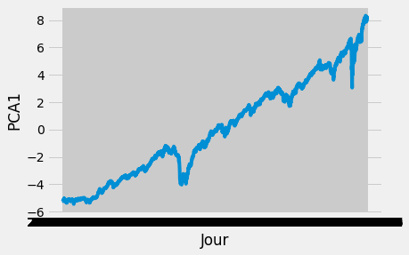

```python
plt.plot(data_pca.index, data_pca.iloc[:,0])
plt.ylabel("PCA1")
plt.xlabel("Jour")
plt.show()
```

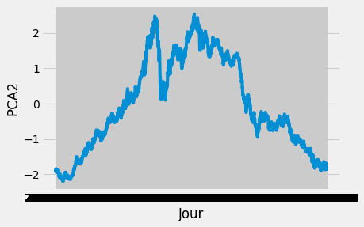

```python
plt.plot(data_pca.index, data_pca.iloc[:,1])
plt.ylabel("PCA2")
plt.xlabel("Jour")
plt.show()
```

Ensuite, nous allons exécuter Kmeans avec les données, pour trouver le nombre approprié de clusters pour chaque fenêtre temporelle, en tenant compte du numéro de la plus grande mesure de silhouette. Nous allons enregistrer un ensemble pour chaque fenêtre comme suit : date de début de fenêtre (date), nombre de clusters choisis (k), taille du cluster avec le plus grand nombre d'éléments (taille), valeur de silhouette plus grande correspondant au cluster k (silhouette), et le résultat du classement des jours dans la fenêtre (clusters).

```python
#X=pd.DataFrame(data_pca1, index=data.index, columns = ['PCA1'])
X=data_t
result = pd.DataFrame(columns = ['date', 'k', 'taille', 'silhouette', 'clusters'])

mapping1 = {}
mapping2 = {}
#series = range(0,5221,21)
series = range(0,1260,21)
K = range(2,11,1)
liste= list(data_t.index.values)
m=0

for serie in series:
    X = data_t[serie:serie+21]
    print("jour ",liste[serie],"à jour ",liste[serie+21])

    silhouette_max = 0
    k_garde=0
    taille=0
    cluster_garde = []
    for k in K:
        kmeanModel = KMeans(n_clusters=k).fit(X)
        kmeanModel.fit(X)

        cluster_labels = kmeanModel.fit_predict(X)
        #print(cluster_labels)

        clusters = pd.DataFrame()
        clusters['label'] = cluster_labels;
        L = range(0,k,1)
        quantite =  pd.DataFrame()
        quantite['cluster']= L
        quantite['quantité']=clusters.groupby('label').size()
        #print(quantite)

        # The silhouette_score gives the average value for all the samples.
        # This gives a perspective into the density and separation of the formed
        # clusters
        silhouette_avg = silhouette_score(X, cluster_labels)
        print(
            "For n_clusters =",
            k,
            "The average silhouette_score is :",
            silhouette_avg,
        )
        if(silhouette_max<silhouette_avg):
            silhouette_max = silhouette_avg;
            k_garde = k;
            taille = quantite['quantité'].max();
            cluster_garde = cluster_labels;


        mapping1[k] = sum(np.min(cdist(X, kmeanModel.cluster_centers_,'euclidean'), axis=1)) / X.shape[0]
      #  mapping2[k] = kmeanModel.inertia_
    m=m+1
    nueva_fila = pd.Series(data={'date':liste[serie], 'k':k_garde, 'taille':taille, 'silhouette':silhouette_max, 'clusters':cluster_garde}, name='x')
    result = result.append(nueva_fila, ignore_index=False)
   # for key, val in mapping1.items():
   #     print(f'{key} : {val}')
```

```
jour  2000-12-29 à jour  2001-01-30
For n_clusters = 2 The average silhouette_score is : 0.38471223810812943
For n_clusters = 3 The average silhouette_score is : 0.37874838525334736
For n_clusters = 4 The average silhouette_score is : 0.3662816151040542
For n_clusters = 5 The average silhouette_score is : 0.36872366973554127
For n_clusters = 6 The average silhouette_score is : 0.29635849355699606
For n_clusters = 7 The average silhouette_score is : 0.30605333534769885
For n_clusters = 8 The average silhouette_score is : 0.26185221775646306
For n_clusters = 9 The average silhouette_score is : 0.27166257450294895
For n_clusters = 10 The average silhouette_score is : 0.22552156819174582
jour  2001-01-30 à jour  2001-02-28
For n_clusters = 2 The average silhouette_score is : 0.49829516234996407
For n_clusters = 3 The average silhouette_score is : 0.4314719600143374
For n_clusters = 4 The average silhouette_score is : 0.378982005770337
For n_clusters = 5 The average silhouette_score is : 0.3373457860492064
For n_clusters = 6 The average silhouette_score is : 0.3210152519466436
For n_clusters = 7 The average silhouette_score is : 0.3231263453234424
For n_clusters = 8 The average silhouette_score is : 0.30492674773576
For n_clusters = 9 The average silhouette_score is : 0.30912587452586865
For n_clusters = 10 The average silhouette_score is : 0.2903948171321391
jour  2001-02-28 à jour  2001-03-29
For n_clusters = 2 The average silhouette_score is : 0.5604253213250724
For n_clusters = 3 The average silhouette_score is : 0.39414035951219034
For n_clusters = 4 The average silhouette_score is : 0.3925921310510141
For n_clusters = 5 The average silhouette_score is : 0.4110603793706578
For n_clusters = 6 The average silhouette_score is : 0.3305661183469392
For n_clusters = 7 The average silhouette_score is : 0.2566630654224892
For n_clusters = 8 The average silhouette_score is : 0.2422667712869796
For n_clusters = 9 The average silhouette_score is : 0.26098848718476997
For n_clusters = 10 The average silhouette_score is : 0.22738074339856643
jour  2001-03-29 à jour  2001-04-30
For n_clusters = 2 The average silhouette_score is : 0.4812817433024266
For n_clusters = 3 The average silhouette_score is : 0.40848147177069255
For n_clusters = 4 The average silhouette_score is : 0.38671011075948847
For n_clusters = 5 The average silhouette_score is : 0.4069634752447439
For n_clusters = 6 The average silhouette_score is : 0.31811844983927845
For n_clusters = 7 The average silhouette_score is : 0.3276364673190499
For n_clusters = 8 The average silhouette_score is : 0.2739439508032225
For n_clusters = 9 The average silhouette_score is : 0.2890354910233718
For n_clusters = 10 The average silhouette_score is : 0.27992828251464924
```

[output cut: 545 more lines]

```
For n_clusters = 6 The average silhouette_score is : 0.35670379442563394
For n_clusters = 7 The average silhouette_score is : 0.3275819379879603
For n_clusters = 8 The average silhouette_score is : 0.3044352809667519
For n_clusters = 9 The average silhouette_score is : 0.2991335772073787
For n_clusters = 10 The average silhouette_score is : 0.29876016169888764
jour  2005-10-17 à jour  2005-11-15
For n_clusters = 2 The average silhouette_score is : 0.5293679086837886
For n_clusters = 3 The average silhouette_score is : 0.3942708029299816
For n_clusters = 4 The average silhouette_score is : 0.30337238911340847
For n_clusters = 5 The average silhouette_score is : 0.3150016521057526
For n_clusters = 6 The average silhouette_score is : 0.29274255453230086
For n_clusters = 7 The average silhouette_score is : 0.3082342235712283
For n_clusters = 8 The average silhouette_score is : 0.3053839057840267
For n_clusters = 9 The average silhouette_score is : 0.27879627770144566
For n_clusters = 10 The average silhouette_score is : 0.26377805035188234
```

```python
print(result)
```

```
         date  k taille  silhouette  \
x  2000-12-29  2     12    0.384712
x  2001-01-30  2     13    0.498295
x  2001-02-28  2     11    0.560425
x  2001-03-29  2     13    0.481282
x  2001-04-30  6      6    0.409842
x  2001-05-29  2     12    0.527297
x  2001-06-27  2     12    0.451208
x  2001-07-26  2     11    0.491605
x  2001-08-24  3     10    0.598750
x  2001-09-24  2     14    0.477313
x  2001-10-23  2     16    0.485443
x  2001-11-21  4      6    0.451504
x  2001-12-20  2     13    0.455237
x  2002-01-22  2     12    0.385777
x  2002-02-20  2     13    0.605330
x  2002-03-21  2     11    0.423061
x  2002-04-22  2     14    0.362992
x  2002-05-21  2     13    0.586614
x  2002-06-19  2     15    0.442409
x  2002-07-18  2     15    0.369566
x  2002-08-16  2     12    0.475685
x  2002-09-16  2     14    0.396284
x  2002-10-15  2     11    0.540587
x  2002-11-13  3     10    0.425468
x  2002-12-12  4      8    0.446178
x  2003-01-14  2     15    0.525919
x  2003-02-12  3      8    0.494386
x  2003-03-13  3     10    0.376991
x  2003-04-11  2     12    0.541346
x  2003-05-13  2     12    0.430021
x  2003-06-11  2     11    0.528578
x  2003-07-10  2     12    0.476196
x  2003-08-08  7      5    0.430276
x  2003-09-08  2     11    0.635885
x  2003-10-07  2     16    0.436727
x  2003-11-05  4     11    0.469846
x  2003-12-04  2     11    0.371000
x  2004-01-06  5      6    0.441670
x  2004-02-04  2     15    0.399462
```

[output cut: 68 more lines]

```
x  [1, 1, 1, 1, 1, 1, 1, 1, 1, 1, 1, 0, 1, 0, 0, ...
x  [0, 0, 0, 0, 0, 0, 0, 0, 0, 0, 0, 0, 0, 0, 0, ...
x  [1, 1, 1, 1, 1, 1, 1, 0, 0, 0, 0, 0, 0, 0, 0, ...
x  [1, 1, 1, 1, 1, 1, 0, 0, 0, 0, 0, 0, 0, 0, 0, ...
x  [0, 0, 0, 0, 0, 0, 0, 1, 1, 1, 1, 1, 1, 1, 1, ...
x  [1, 1, 1, 1, 1, 1, 1, 1, 1, 0, 0, 0, 0, 0, 0, ...
x  [0, 0, 0, 0, 0, 0, 0, 0, 0, 0, 0, 1, 1, 1, 1, ...
x  [0, 0, 0, 0, 0, 0, 0, 0, 0, 0, 0, 0, 0, 0, 0, ...
x  [1, 1, 1, 1, 1, 1, 1, 1, 1, 1, 1, 1, 1, 1, 0, ...
x  [1, 1, 1, 1, 1, 1, 0, 0, 0, 0, 0, 0, 0, 0, 2, ...
x  [1, 1, 1, 1, 1, 1, 1, 1, 2, 2, 2, 2, 2, 2, 0, ...
x  [1, 1, 1, 1, 1, 1, 1, 1, 1, 0, 0, 0, 0, 0, 0, ...
x  [0, 0, 0, 0, 0, 0, 0, 0, 0, 1, 1, 1, 1, 1, 1, ...
x  [2, 2, 2, 2, 2, 2, 2, 2, 1, 1, 1, 1, 1, 0, 0, ...
x  [0, 0, 0, 0, 0, 0, 0, 0, 0, 0, 1, 1, 1, 1, 1, ...
```

```python
L = range(0,11,1)
quantite =  pd.DataFrame()
quantite['cluster']= L
quantite['quantité']=result.groupby('k').size()
print(quantite)
```

```
    cluster  quantité
0         0       NaN
1         1       NaN
2         2      44.0
3         3       9.0
4         4       3.0
5         5       1.0
6         6       2.0
7         7       1.0
8         8       NaN
9         9       NaN
10       10       NaN
```

Ensuite, le score rand est calculé.

```python
rows = len(result)
rand_list = range(1,rows,1)
print(rows)

rand_sco = []
clusters = result['clusters']

for rand in rand_list:
     labels_true = clusters[rand-1]
     labels_pred = clusters[rand]
     score = rand_score(labels_true, labels_pred)
     rand_sco.append(score)
```

```
60
```

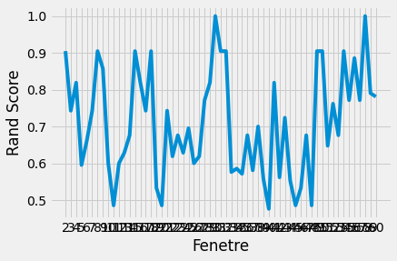

```python
plt.style.use("fivethirtyeight")
plt.plot(range(2, rows+1), rand_sco)
plt.xticks(range(2, rows+1))
plt.xlabel("Fenetre")
plt.ylabel("Rand Score")
plt.show()
```

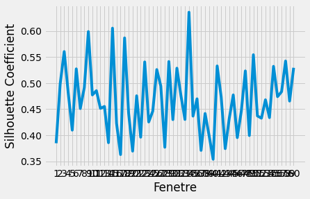

```python
plt.style.use("fivethirtyeight")
plt.style.use("fivethirtyeight")
plt.plot(range(1, rows+1), result['silhouette'])
plt.xticks(range(1, rows+1))
plt.xlabel("Fenetre")
plt.ylabel("Silhouette Coefficient")
plt.show()
```

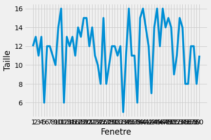

```python
plt.style.use("fivethirtyeight")
plt.style.use("fivethirtyeight")
plt.plot(range(1, rows+1), result['taille'])
plt.xticks(range(1, rows+1))
plt.xlabel("Fenetre")
plt.ylabel("Taille")
plt.show()
```

Nous traçons le coefficient de silhouette, la plus grande taille de cluster et le score rand, et certaines données aberrantes sont observées.

Ensuite, nous allons exécuter l'algorithme DTW. On applique la fonction distance DTW selon la théorie et les références jointes à la fin. Ensuite, un Kmeans est appliqué qui utilise la distance DTW comme base pour le calcul des clusters.

```python
def DTWDistance(s1, s2,w):
    DTW={}

    w = max(w, abs(len(s1)-len(s2)))

    for i in range(-1,len(s1)):
        for j in range(-1,len(s2)):
            DTW[(i, j)] = float('inf')
    DTW[(-1, -1)] = 0

    for i in range(len(s1)):
        for j in range(max(0, i-w), min(len(s2), i+w)):
            dist= (s1[i]-s2[j])**2
            DTW[(i, j)] = dist + min(DTW[(i-1, j)],DTW[(i, j-1)], DTW[(i-1, j-1)])

    return math.sqrt(DTW[len(s1)-1, len(s2)-1])
```

```python
def LB_Keogh(s1,s2,r):
    LB_sum=0
    for ind,i in enumerate(s1):

        lower_bound=min(s2[(ind-r if ind-r>=0 else 0):(ind+r)])
        upper_bound=max(s2[(ind-r if ind-r>=0 else 0):(ind+r)])

        if i>upper_bound:
            LB_sum=LB_sum+(i-upper_bound)**2
        elif i<lower_bound:
            LB_sum=LB_sum+(i-lower_bound)**2

    return math.sqrt(LB_sum)
```

```python
import random

def k_means_clust(data,num_clust,num_iter,w=5):
    #rows = random.sample(data,num_clust)
    centroids = random.sample(list(data),num_clust)
    counter=0
    #print (centroids)
    for n in range(num_iter):
        counter+=1
        m=0
        assignments={}
        assignments_list = []
        #assign data points to clusters
        for ind,i in enumerate(data):
            min_dist=float('inf')
            closest_clust=None
            #print(centroids)
            for c_ind,j in enumerate(centroids):
               # if LB_Keogh(i,j,5)<=min_dist:
                    cur_dist=DTWDistance(i,j,w)
                    if cur_dist<=min_dist:
                        min_dist=cur_dist
                        closest_clust=c_ind
            if closest_clust in assignments:
                assignments[closest_clust].append(ind)
                assignments_list.append(closest_clust)
            else:
                assignments[closest_clust]=[]
                assignments_list.append(closest_clust)

        #recalculate centroids of clusters
        for key in assignments:
            clust_sum=0
            for k in assignments[key]:
                clust_sum=clust_sum+data[k]
            #centroids[key]=[m/len(assignments[key]) for m in range(0,len(clust_sum))]
            if(assignments[key]!=[]):
                centroids[key]=[m/len(assignments[key]) for m in clust_sum]
            #for m in range(len(clust_sum)):
            #    centroids[key]=[m/len(assignments[key])]

    return assignments_list
```

```python
X=data_pca
result2 = pd.DataFrame(columns = ['date', 'k', 'taille', 'silhouette'])

mapping1 = {}
mapping2 = {}
#series = range(0,5221,21)
series = range(0,1260,21)


for serie in series:
    X = data_pca[serie:serie+21]
    datadtw=np.vstack((data_pca[serie-21:serie-1],data_pca[serie:serie+21]))
    silhouette_max = 0
    for k in K:
        centroids=k_means_clust(datadtw,k,4,4)
        #for i in centroids:
        #    plt.plot(i)
        #    plt.show()

        # The silhouette_score gives the average value for all the samples.
        # This gives a perspective into the density and separation of the formed
        # clusters
        #print(centroids)
        silhouette_avg = silhouette_score(datadtw, list(centroids))

        clusters = pd.DataFrame()
        clusters['label'] = centroids;
        L = range(0,k,1)
        quantite =  pd.DataFrame()
        quantite['cluster']= L
        quantite['quantité']=clusters.groupby('label').size()
        #print(quantite)

        print(
            "For n_clusters =",
            k,
            "The average silhouette_score is :",
            silhouette_avg,
        )
        if(silhouette_max<silhouette_avg):
            silhouette_max = silhouette_avg;
            k_garde = k;
            taille = quantite['quantité'].max();
            cluster_garde = centroids;

    m=m+1
    nueva_fila = pd.Series(data={'date':liste[serie], 'k':k_garde, 'taille':taille, 'silhouette':silhouette_max, 'clusters':cluster_garde}, name='x')
    result2 = result2.append(nueva_fila, ignore_index=False)
```

```
For n_clusters = 2 The average silhouette_score is : 0.991897613530805
For n_clusters = 3 The average silhouette_score is : 0.7991234823444437
For n_clusters = 4 The average silhouette_score is : 0.6956492987399461
For n_clusters = 5 The average silhouette_score is : 0.4827628501628607
For n_clusters = 6 The average silhouette_score is : 0.4372201778378126
For n_clusters = 7 The average silhouette_score is : 0.4787979064618749
For n_clusters = 8 The average silhouette_score is : 0.3446121389176373
For n_clusters = 9 The average silhouette_score is : 0.4054257800911587
For n_clusters = 10 The average silhouette_score is : 0.3899991885012414
For n_clusters = 2 The average silhouette_score is : 0.41390249555716657
For n_clusters = 3 The average silhouette_score is : 0.5158610654812997
For n_clusters = 4 The average silhouette_score is : 0.44794604565341806
For n_clusters = 5 The average silhouette_score is : 0.37803322242160825
For n_clusters = 6 The average silhouette_score is : 0.3425803434507111
For n_clusters = 7 The average silhouette_score is : 0.3866081305932745
For n_clusters = 8 The average silhouette_score is : 0.3008665351354842
For n_clusters = 9 The average silhouette_score is : 0.3758782982038982
For n_clusters = 10 The average silhouette_score is : 0.3456407705728565
For n_clusters = 2 The average silhouette_score is : 0.5729988492174216
For n_clusters = 3 The average silhouette_score is : 0.41065251087513044
For n_clusters = 4 The average silhouette_score is : 0.44218877276619006
For n_clusters = 5 The average silhouette_score is : 0.3749241908293541
For n_clusters = 6 The average silhouette_score is : 0.3313619145761306
For n_clusters = 7 The average silhouette_score is : 0.3617081039189268
For n_clusters = 8 The average silhouette_score is : 0.37284677062926097
For n_clusters = 9 The average silhouette_score is : 0.35437268695484553
For n_clusters = 10 The average silhouette_score is : 0.30374875422655345
For n_clusters = 2 The average silhouette_score is : 0.4036365940585412
For n_clusters = 3 The average silhouette_score is : 0.48450692647383126
For n_clusters = 4 The average silhouette_score is : 0.38847356915860987
For n_clusters = 5 The average silhouette_score is : 0.4210802909116604
For n_clusters = 6 The average silhouette_score is : 0.45739921143429174
For n_clusters = 7 The average silhouette_score is : 0.4094741906863494
For n_clusters = 8 The average silhouette_score is : 0.46259688313077096
For n_clusters = 9 The average silhouette_score is : 0.3078578295549992
For n_clusters = 10 The average silhouette_score is : 0.31088264658465575
For n_clusters = 2 The average silhouette_score is : 0.5950929870937373
For n_clusters = 3 The average silhouette_score is : 0.5054186940236851
For n_clusters = 4 The average silhouette_score is : 0.43850732864360004
For n_clusters = 5 The average silhouette_score is : 0.4018941962823331
```

[output cut: 485 more lines]

```
For n_clusters = 5 The average silhouette_score is : 0.4301762608564851
For n_clusters = 6 The average silhouette_score is : 0.3714017172627192
For n_clusters = 7 The average silhouette_score is : 0.48623677553734235
For n_clusters = 8 The average silhouette_score is : 0.4430063930065476
For n_clusters = 9 The average silhouette_score is : 0.30490755239018263
For n_clusters = 10 The average silhouette_score is : 0.4672129322500194
For n_clusters = 2 The average silhouette_score is : 0.6369854546941119
For n_clusters = 3 The average silhouette_score is : 0.5540452876336244
For n_clusters = 4 The average silhouette_score is : 0.4712028811108193
For n_clusters = 5 The average silhouette_score is : 0.48273581613800914
For n_clusters = 6 The average silhouette_score is : 0.4269245048993966
For n_clusters = 7 The average silhouette_score is : 0.3701847963764688
For n_clusters = 8 The average silhouette_score is : 0.4926801195461092
For n_clusters = 9 The average silhouette_score is : 0.4449281968925388
For n_clusters = 10 The average silhouette_score is : 0.38160797958758186
```

```python
print(result2)
```

```
         date   k taille  silhouette  \
x  2000-12-29   2     21    0.991898
x  2001-01-30   3     15    0.515861
x  2001-02-28   2     25    0.572999
x  2001-03-29   3     16    0.484507
x  2001-04-30   2     22    0.595093
x  2001-05-29   3     17    0.426122
x  2001-06-27   2     21    0.549116
x  2001-07-26   2     23    0.575339
x  2001-08-24   4     14    0.628617
x  2001-09-24   3     22    0.579064
x  2001-10-23   3     20    0.528407
x  2001-11-21   3     20    0.510619
x  2001-12-20   2     21    0.500534
x  2002-01-22   4     13    0.470700
x  2002-02-20   3     19    0.532838
x  2002-03-21   2     37    0.547219
x  2002-04-22   2     21    0.666630
x  2002-05-21   2     21    0.647158
x  2002-06-19   2     23    0.698562
x  2002-07-18   3     21    0.497376
x  2002-08-16   3     22    0.590793
x  2002-09-16   2     34    0.648939
x  2002-10-15   2     23    0.547718
x  2002-11-13   2     29    0.705367
x  2002-12-12   2     22    0.672075
x  2003-01-14   2     22    0.531616
x  2003-02-12   3     18    0.536091
x  2003-03-13   3     18    0.471855
x  2003-04-11   2     27    0.608437
x  2003-05-13   2     25    0.678230
x  2003-06-11   3     20    0.510983
x  2003-07-10   2     23    0.567711
x  2003-08-08   2     22    0.457291
x  2003-09-08   2     21    0.628359
x  2003-10-07   2     29    0.657812
x  2003-11-05   2     26    0.548792
x  2003-12-04   2     24    0.568054
x  2004-01-06   2     21    0.667055
x  2004-02-04   9     12    0.471637
```

[output cut: 68 more lines]

```
x  [0, 0, 0, 0, 0, 0, 0, 0, 0, 0, 0, 0, 0, 0, 0, ...
x  [3, 3, 3, 3, 3, 3, 3, 3, 3, 3, 3, 1, 3, 1, 1, ...
x  [1, 1, 1, 1, 1, 1, 1, 1, 1, 1, 1, 1, 1, 1, 1, ...
x  [1, 1, 1, 1, 1, 1, 1, 1, 1, 1, 1, 1, 1, 1, 1, ...
x  [1, 1, 1, 1, 1, 1, 1, 1, 1, 0, 0, 0, 0, 0, 2, ...
x  [2, 2, 2, 2, 2, 2, 2, 0, 0, 0, 0, 0, 0, 1, 1, ...
x  [1, 1, 1, 1, 1, 1, 1, 1, 1, 1, 1, 1, 1, 1, 1, ...
x  [0, 0, 0, 0, 0, 0, 0, 0, 0, 0, 0, 0, 0, 0, 0, ...
x  [0, 0, 0, 0, 0, 0, 0, 0, 0, 0, 0, 0, 0, 0, 0, ...
x  [0, 0, 0, 0, 0, 0, 0, 0, 0, 0, 0, 0, 0, 0, 0, ...
x  [0, 0, 0, 0, 0, 0, 0, 0, 1, 0, 1, 1, 1, 1, 0, ...
x  [0, 0, 0, 0, 0, 0, 0, 0, 0, 0, 0, 0, 0, 0, 0, ...
x  [2, 2, 2, 2, 2, 2, 2, 2, 2, 0, 0, 0, 0, 0, 0, ...
x  [2, 2, 2, 2, 2, 2, 2, 2, 2, 1, 1, 1, 1, 1, 1, ...
x  [0, 0, 0, 0, 0, 0, 0, 0, 0, 0, 0, 0, 0, 0, 0, ...
```

```python
L = range(0,11,1)
quantite =  pd.DataFrame()
quantite['cluster']= L
quantite['quantité']=result2.groupby('k').size()
print(quantite)
```

```
    cluster  quantité
0         0       NaN
1         1       NaN
2         2      37.0
3         3      13.0
4         4       5.0
5         5       2.0
6         6       1.0
7         7       NaN
8         8       NaN
9         9       1.0
10       10       1.0
```

```python
rows = len(result2)
rand_list = range(1,rows,1)
print(rows)

rand_sco2 = []
clusters = result2['clusters']

for rand in rand_list:
     labels_true = clusters[rand-1]
     labels_pred = clusters[rand]
     score = rand_score(labels_true, labels_pred)
     rand_sco2.append(score)
```

```
60
```

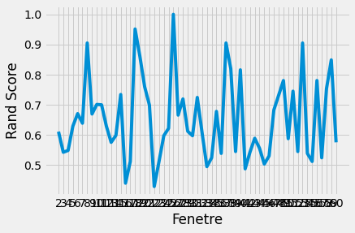

```python
plt.style.use("fivethirtyeight")
plt.plot(range(2, rows+1), rand_sco2)
plt.xticks(range(2, rows+1))
plt.xlabel("Fenetre")
plt.ylabel("Rand Score")
plt.show()
```

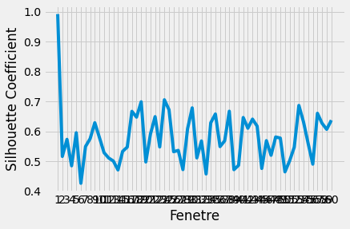

```python
plt.style.use("fivethirtyeight")
plt.plot(range(1, rows+1), result2['silhouette'])
plt.xticks(range(1, rows+1))
plt.xlabel("Fenetre")
plt.ylabel("Silhouette Coefficient")
plt.show()
```

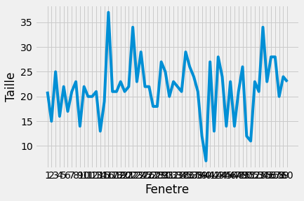

```python
plt.style.use("fivethirtyeight")
plt.style.use("fivethirtyeight")
plt.plot(range(1, rows+1), result2['taille'])
plt.xticks(range(1, rows+1))
plt.xlabel("Fenetre")
plt.ylabel("Taille")
plt.show()
```

Nous traçons le coefficient de silhouette, la plus grande taille de cluster et le score rand, et certaines données aberrantes sont observées.

Références

https://scikit-learn.org/stable/auto_examples/cluster/plot_kmeans_silhouette_analysis.html

https://towardsdatascience.com/how-to-apply-k-means-clustering-to-time-series-data-28d04a8f7da3

https://dtaidistance.readthedocs.io/en/latest/usage/dtw.html

https://rstudio-pubs-static.s3.amazonaws.com/474160_0761428e8683401e941a92a4177254a4.html

https://nbviewer.ipython.org/github/alexminnaar/time-series-classification-and-clustering/blob/master/Time%20Series%20Classification%20and%20Clustering.ipynb

http://alexminnaar.com/2014/04/16/Time-Series-Classification-and-Clustering-with-Python.html

https://realpython.com/k-means-clustering-python/